# Risk Factor Analysis

## Outcome Variable

**Outcome Variable:** dead

## Predictor Variables

**Intervention Variable:** ever_wasted06

**Adjustment Set:**

- sex
- arm
- enstunt
- month
- brthmon
- vagbrth
- impfloor
- earlybf
- hhwealth_quart
- W_birthwt
- W_birthlen
- W_mage
- W_mhtcm
- W_meducyrs
- W_feducyrs
- W_nrooms
- W_nchldlt5
- W_parity
- impsan
- safeh20
- predexfd6
- delta_month
- delta_brthmon
- delta_vagbrth
- delta_impfloor
- delta_earlybf
- delta_hhwealth_quart
- delta_W_birthwt
- delta_W_birthlen
- delta_W_mage
- delta_W_mhtcm
- delta_W_meducyrs
- delta_W_feducyrs
- delta_W_nrooms
- delta_W_nchldlt5
- delta_W_parity
- delta_impsan
- delta_safeh20
- delta_predexfd6

## Stratifying Variables

The analysis was stratified on these variable(s):

- studyid
- country

## Data Summary

| studyid | country | ever_wasted06 | dead | n_cell | n |
| --- | --- | --- | --- | --- | --- |
| ki0047075b-MAL-ED | BANGLADESH | 0 | 0 | 202 | 263 |
| ki0047075b-MAL-ED | BANGLADESH | 0 | 1 | 2 | 263 |
| ki0047075b-MAL-ED | BANGLADESH | 1 | 0 | 59 | 263 |
| ki0047075b-MAL-ED | BANGLADESH | 1 | 1 | 0 | 263 |
| ki0047075b-MAL-ED | INDIA | 0 | 0 | 169 | 251 |
| ki0047075b-MAL-ED | INDIA | 0 | 1 | 1 | 251 |
| ki0047075b-MAL-ED | INDIA | 1 | 0 | 80 | 251 |
| ki0047075b-MAL-ED | INDIA | 1 | 1 | 1 | 251 |
| ki0047075b-MAL-ED | PERU | 0 | 0 | 289 | 302 |
| ki0047075b-MAL-ED | PERU | 0 | 1 | 2 | 302 |
| ki0047075b-MAL-ED | PERU | 1 | 0 | 11 | 302 |
| ki0047075b-MAL-ED | PERU | 1 | 1 | 0 | 302 |
| ki0047075b-MAL-ED | SOUTH AFRICA | 0 | 0 | 279 | 312 |
| ki0047075b-MAL-ED | SOUTH AFRICA | 0 | 1 | 0 | 312 |
| ki0047075b-MAL-ED | SOUTH AFRICA | 1 | 0 | 33 | 312 |
| ki0047075b-MAL-ED | SOUTH AFRICA | 1 | 1 | 0 | 312 |
| ki0047075b-MAL-ED | TANZANIA, UNITED REPUBLIC OF | 0 | 0 | 246 | 261 |
| ki0047075b-MAL-ED | TANZANIA, UNITED REPUBLIC OF | 0 | 1 | 3 | 261 |
| ki0047075b-MAL-ED | TANZANIA, UNITED REPUBLIC OF | 1 | 0 | 12 | 261 |
| ki0047075b-MAL-ED | TANZANIA, UNITED REPUBLIC OF | 1 | 1 | 0 | 261 |
| ki1000304-VITAMIN-A | INDIA | 0 | 0 | 2812 | 3473 |
| ki1000304-VITAMIN-A | INDIA | 0 | 1 | 35 | 3473 |
| ki1000304-VITAMIN-A | INDIA | 1 | 0 | 603 | 3473 |
| ki1000304-VITAMIN-A | INDIA | 1 | 1 | 23 | 3473 |
| ki1000304b-SAS-CompFeed | INDIA | 0 | 0 | 1142 | 1508 |
| ki1000304b-SAS-CompFeed | INDIA | 0 | 1 | 22 | 1508 |
| ki1000304b-SAS-CompFeed | INDIA | 1 | 0 | 330 | 1508 |
| ki1000304b-SAS-CompFeed | INDIA | 1 | 1 | 14 | 1508 |
| ki1000304b-SAS-FoodSuppl | INDIA | 0 | 0 | 316 | 418 |
| ki1000304b-SAS-FoodSuppl | INDIA | 0 | 1 | 2 | 418 |
| ki1000304b-SAS-FoodSuppl | INDIA | 1 | 0 | 96 | 418 |
| ki1000304b-SAS-FoodSuppl | INDIA | 1 | 1 | 4 | 418 |
| ki1017093b-PROVIDE | BANGLADESH | 0 | 0 | 514 | 699 |
| ki1017093b-PROVIDE | BANGLADESH | 0 | 1 | 4 | 699 |
| ki1017093b-PROVIDE | BANGLADESH | 1 | 0 | 181 | 699 |
| ki1017093b-PROVIDE | BANGLADESH | 1 | 1 | 0 | 699 |
| ki1066203-TanzaniaChild2 | TANZANIA, UNITED REPUBLIC OF | 0 | 0 | 2038 | 2396 |
| ki1066203-TanzaniaChild2 | TANZANIA, UNITED REPUBLIC OF | 0 | 1 | 1 | 2396 |
| ki1066203-TanzaniaChild2 | TANZANIA, UNITED REPUBLIC OF | 1 | 0 | 357 | 2396 |
| ki1066203-TanzaniaChild2 | TANZANIA, UNITED REPUBLIC OF | 1 | 1 | 0 | 2396 |
| ki1101329-Keneba | GAMBIA | 0 | 0 | 1990 | 2422 |
| ki1101329-Keneba | GAMBIA | 0 | 1 | 40 | 2422 |
| ki1101329-Keneba | GAMBIA | 1 | 0 | 375 | 2422 |
| ki1101329-Keneba | GAMBIA | 1 | 1 | 17 | 2422 |
| ki1112895-Burkina Faso Zn | BURKINA FASO | 0 | 0 | 296 | 338 |
| ki1112895-Burkina Faso Zn | BURKINA FASO | 0 | 1 | 2 | 338 |
| ki1112895-Burkina Faso Zn | BURKINA FASO | 1 | 0 | 40 | 338 |
| ki1112895-Burkina Faso Zn | BURKINA FASO | 1 | 1 | 0 | 338 |
| ki1113344-GMS-Nepal | NEPAL | 0 | 0 | 418 | 602 |
| ki1113344-GMS-Nepal | NEPAL | 0 | 1 | 4 | 602 |
| ki1113344-GMS-Nepal | NEPAL | 1 | 0 | 179 | 602 |
| ki1113344-GMS-Nepal | NEPAL | 1 | 1 | 1 | 602 |
| ki1126311-ZVITAMBO | ZIMBABWE | 0 | 0 | 10489 | 13849 |
| ki1126311-ZVITAMBO | ZIMBABWE | 0 | 1 | 728 | 13849 |
| ki1126311-ZVITAMBO | ZIMBABWE | 1 | 0 | 2313 | 13849 |
| ki1126311-ZVITAMBO | ZIMBABWE | 1 | 1 | 319 | 13849 |
| ki1148112-iLiNS-DOSE | MALAWI | 0 | 0 | 1675 | 1814 |
| ki1148112-iLiNS-DOSE | MALAWI | 0 | 1 | 110 | 1814 |
| ki1148112-iLiNS-DOSE | MALAWI | 1 | 0 | 25 | 1814 |
| ki1148112-iLiNS-DOSE | MALAWI | 1 | 1 | 4 | 1814 |
| ki1148112-iLiNS-DYAD-M | MALAWI | 0 | 0 | 1089 | 1179 |
| ki1148112-iLiNS-DYAD-M | MALAWI | 0 | 1 | 33 | 1179 |
| ki1148112-iLiNS-DYAD-M | MALAWI | 1 | 0 | 52 | 1179 |
| ki1148112-iLiNS-DYAD-M | MALAWI | 1 | 1 | 5 | 1179 |
| kiGH5241-JiVitA-3 | BANGLADESH | 0 | 0 | 21054 | 26882 |
| kiGH5241-JiVitA-3 | BANGLADESH | 0 | 1 | 399 | 26882 |
| kiGH5241-JiVitA-3 | BANGLADESH | 1 | 0 | 5267 | 26882 |
| kiGH5241-JiVitA-3 | BANGLADESH | 1 | 1 | 162 | 26882 |
| kiGH5241-JiVitA-4 | BANGLADESH | 0 | 0 | 4520 | 5251 |
| kiGH5241-JiVitA-4 | BANGLADESH | 0 | 1 | 37 | 5251 |
| kiGH5241-JiVitA-4 | BANGLADESH | 1 | 0 | 684 | 5251 |
| kiGH5241-JiVitA-4 | BANGLADESH | 1 | 1 | 10 | 5251 |

The following strata were considered:

- studyid: ki0047075b-MAL-ED, country: BANGLADESH
- studyid: ki0047075b-MAL-ED, country: INDIA
- studyid: ki0047075b-MAL-ED, country: PERU
- studyid: ki0047075b-MAL-ED, country: SOUTH AFRICA
- studyid: ki0047075b-MAL-ED, country: TANZANIA, UNITED REPUBLIC OF
- studyid: ki1000304-VITAMIN-A, country: INDIA
- studyid: ki1000304b-SAS-CompFeed, country: INDIA
- studyid: ki1000304b-SAS-FoodSuppl, country: INDIA
- studyid: ki1017093b-PROVIDE, country: BANGLADESH
- studyid: ki1066203-TanzaniaChild2, country: TANZANIA, UNITED REPUBLIC OF
- studyid: ki1101329-Keneba, country: GAMBIA
- studyid: ki1112895-Burkina Faso Zn, country: BURKINA FASO
- studyid: ki1113344-GMS-Nepal, country: NEPAL
- studyid: ki1126311-ZVITAMBO, country: ZIMBABWE
- studyid: ki1148112-iLiNS-DOSE, country: MALAWI
- studyid: ki1148112-iLiNS-DYAD-M, country: MALAWI
- studyid: kiGH5241-JiVitA-3, country: BANGLADESH
- studyid: kiGH5241-JiVitA-4, country: BANGLADESH

### Dropped Strata

Some strata were dropped due to rare outcomes:

- studyid: ki0047075b-MAL-ED, country: BANGLADESH
- studyid: ki0047075b-MAL-ED, country: INDIA
- studyid: ki0047075b-MAL-ED, country: PERU
- studyid: ki0047075b-MAL-ED, country: SOUTH AFRICA
- studyid: ki0047075b-MAL-ED, country: TANZANIA, UNITED REPUBLIC OF
- studyid: ki1000304b-SAS-FoodSuppl, country: INDIA
- studyid: ki1017093b-PROVIDE, country: BANGLADESH
- studyid: ki1066203-TanzaniaChild2, country: TANZANIA, UNITED REPUBLIC OF
- studyid: ki1112895-Burkina Faso Zn, country: BURKINA FASO
- studyid: ki1113344-GMS-Nepal, country: NEPAL
- studyid: ki1148112-iLiNS-DOSE, country: MALAWI

## Methods Detail

We’re interested in the causal parameters $E[Y_a]$ for all values of $a \in \mathcal{A}$. These parameters represent the mean outcome if, possibly contrary to fact, we intervened to set all units to have $A=a$. Under the randomization and positivity assumptions, these are identified by the statistical parameters $\psi_a=E_W[E_{Y|A,W}(Y|A=a,W)]$. In addition, we’re interested in the mean of $Y$, $E[Y]$ under no intervention (the observed mean). We will estimate these parameters by using SuperLearner to fit the relevant likelihood factors – $E_{Y|A,W}(Y|A=a,W)$ and $p(A=a|W)$, and then updating our likelihood fit using a joint TMLE.

For unadjusted analyses ($W=\{\}$), initial likelihoods were estimated using Lrnr_glm to estimate the simple $E(Y|A)$ and Lrnr_mean to estimate $p(A)$. For adjusted analyses, a small library containing Lrnr_glmnet, Lrnr_xgboost, and Lrnr_mean was used.

Having estimated these parameters, we will then use the delta method to estimate relative risks and attributable risks relative to a prespecified baseline level of $A$.

# Results Detail

## Results Plots

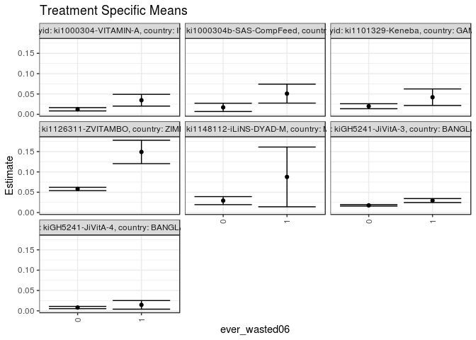

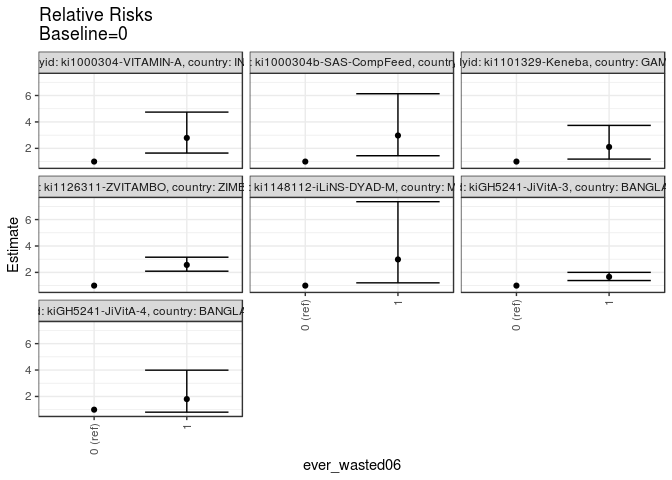

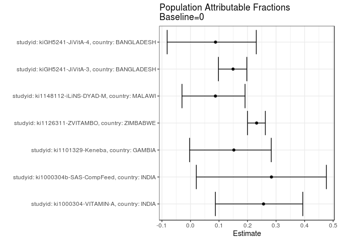

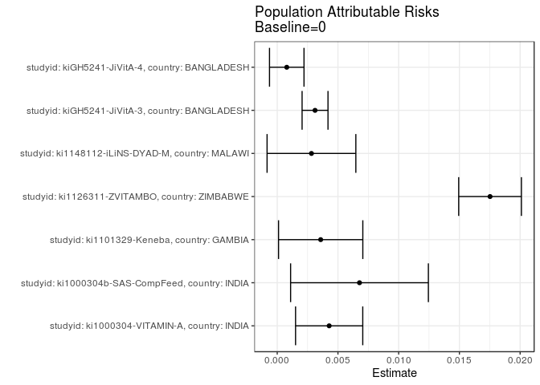

## Results Table

### Parameter: TSM

| studyid | country | intervention_level | baseline_level | estimate | ci_lower | ci_upper |
| --- | --- | --- | --- | --- | --- | --- |
| ki1000304-VITAMIN-A | INDIA | 0 | NA | 0.0124238 | 0.0083636 | 0.0164840 |
| ki1000304-VITAMIN-A | INDIA | 1 | NA | 0.0346889 | 0.0201823 | 0.0491955 |
| ki1000304b-SAS-CompFeed | INDIA | 0 | NA | 0.0170989 | 0.0069618 | 0.0272360 |
| ki1000304b-SAS-CompFeed | INDIA | 1 | NA | 0.0508575 | 0.0275343 | 0.0741806 |
| ki1101329-Keneba | GAMBIA | 0 | NA | 0.0199562 | 0.0138201 | 0.0260923 |
| ki1101329-Keneba | GAMBIA | 1 | NA | 0.0420295 | 0.0216893 | 0.0623697 |
| ki1126311-ZVITAMBO | ZIMBABWE | 0 | NA | 0.0580771 | 0.0539791 | 0.0621751 |
| ki1126311-ZVITAMBO | ZIMBABWE | 1 | NA | 0.1490979 | 0.1203544 | 0.1778414 |
| ki1148112-iLiNS-DYAD-M | MALAWI | 0 | NA | 0.0294118 | 0.0195214 | 0.0393022 |
| ki1148112-iLiNS-DYAD-M | MALAWI | 1 | NA | 0.0877193 | 0.0142499 | 0.1611887 |
| kiGH5241-JiVitA-3 | BANGLADESH | 0 | NA | 0.0177547 | 0.0159297 | 0.0195798 |
| kiGH5241-JiVitA-3 | BANGLADESH | 1 | NA | 0.0295799 | 0.0247056 | 0.0344543 |
| kiGH5241-JiVitA-4 | BANGLADESH | 0 | NA | 0.0081653 | 0.0053783 | 0.0109524 |
| kiGH5241-JiVitA-4 | BANGLADESH | 1 | NA | 0.0147042 | 0.0041024 | 0.0253060 |

### Parameter: E(Y)

| studyid | country | intervention_level | baseline_level | estimate | ci_lower | ci_upper |
| --- | --- | --- | --- | --- | --- | --- |
| ki1000304-VITAMIN-A | INDIA | NA | NA | 0.0167003 | 0.0124378 | 0.0209627 |
| ki1000304b-SAS-CompFeed | INDIA | NA | NA | 0.0238727 | 0.0131072 | 0.0346381 |
| ki1101329-Keneba | GAMBIA | NA | NA | 0.0235343 | 0.0174958 | 0.0295728 |
| ki1126311-ZVITAMBO | ZIMBABWE | NA | NA | 0.0756011 | 0.0711981 | 0.0800041 |
| ki1148112-iLiNS-DYAD-M | MALAWI | NA | NA | 0.0322307 | 0.0221452 | 0.0423162 |
| kiGH5241-JiVitA-3 | BANGLADESH | NA | NA | 0.0208690 | 0.0191196 | 0.0226184 |
| kiGH5241-JiVitA-4 | BANGLADESH | NA | NA | 0.0089507 | 0.0062400 | 0.0116614 |

### Parameter: RR

| studyid | country | intervention_level | baseline_level | estimate | ci_lower | ci_upper |
| --- | --- | --- | --- | --- | --- | --- |
| ki1000304-VITAMIN-A | INDIA | 0 | 0 | 1.000000 | 1.0000000 | 1.000000 |
| ki1000304-VITAMIN-A | INDIA | 1 | 0 | 2.792132 | 1.6432098 | 4.744373 |
| ki1000304b-SAS-CompFeed | INDIA | 0 | 0 | 1.000000 | 1.0000000 | 1.000000 |
| ki1000304b-SAS-CompFeed | INDIA | 1 | 0 | 2.974310 | 1.4417015 | 6.136166 |
| ki1101329-Keneba | GAMBIA | 0 | 0 | 1.000000 | 1.0000000 | 1.000000 |
| ki1101329-Keneba | GAMBIA | 1 | 0 | 2.106087 | 1.1868689 | 3.737229 |
| ki1126311-ZVITAMBO | ZIMBABWE | 0 | 0 | 1.000000 | 1.0000000 | 1.000000 |
| ki1126311-ZVITAMBO | ZIMBABWE | 1 | 0 | 2.567241 | 2.0911940 | 3.151657 |
| ki1148112-iLiNS-DYAD-M | MALAWI | 0 | 0 | 1.000000 | 1.0000000 | 1.000000 |
| ki1148112-iLiNS-DYAD-M | MALAWI | 1 | 0 | 2.982456 | 1.2095040 | 7.354291 |
| kiGH5241-JiVitA-3 | BANGLADESH | 0 | 0 | 1.000000 | 1.0000000 | 1.000000 |
| kiGH5241-JiVitA-3 | BANGLADESH | 1 | 0 | 1.666032 | 1.3849741 | 2.004125 |
| kiGH5241-JiVitA-4 | BANGLADESH | 0 | 0 | 1.000000 | 1.0000000 | 1.000000 |
| kiGH5241-JiVitA-4 | BANGLADESH | 1 | 0 | 1.800811 | 0.8127602 | 3.990010 |

### Parameter: PAR

| studyid | country | intervention_level | baseline_level | estimate | ci_lower | ci_upper |
| --- | --- | --- | --- | --- | --- | --- |
| ki1000304-VITAMIN-A | INDIA | 0 | NA | 0.0042764 | 0.0015101 | 0.0070428 |
| ki1000304b-SAS-CompFeed | INDIA | 0 | NA | 0.0067738 | 0.0011019 | 0.0124456 |
| ki1101329-Keneba | GAMBIA | 0 | NA | 0.0035781 | 0.0001085 | 0.0070476 |
| ki1126311-ZVITAMBO | ZIMBABWE | 0 | NA | 0.0175240 | 0.0149423 | 0.0201058 |
| ki1148112-iLiNS-DYAD-M | MALAWI | 0 | NA | 0.0028189 | -0.0008355 | 0.0064734 |
| kiGH5241-JiVitA-3 | BANGLADESH | 0 | NA | 0.0031143 | 0.0020476 | 0.0041809 |
| kiGH5241-JiVitA-4 | BANGLADESH | 0 | NA | 0.0007853 | -0.0006350 | 0.0022057 |

### Parameter: PAF

| studyid | country | intervention_level | baseline_level | estimate | ci_lower | ci_upper |
| --- | --- | --- | --- | --- | --- | --- |
| ki1000304-VITAMIN-A | INDIA | 0 | NA | 0.2560708 | 0.0872893 | 0.3936406 |
| ki1000304b-SAS-CompFeed | INDIA | 0 | NA | 0.2837457 | 0.0204933 | 0.4762464 |
| ki1101329-Keneba | GAMBIA | 0 | NA | 0.1520368 | -0.0030180 | 0.2831219 |
| ki1126311-ZVITAMBO | ZIMBABWE | 0 | NA | 0.2317959 | 0.1999612 | 0.2623638 |
| ki1148112-iLiNS-DYAD-M | MALAWI | 0 | NA | 0.0874613 | -0.0297126 | 0.1913017 |
| kiGH5241-JiVitA-3 | BANGLADESH | 0 | NA | 0.1492291 | 0.0980326 | 0.1975196 |
| kiGH5241-JiVitA-4 | BANGLADESH | 0 | NA | 0.0877405 | -0.0816394 | 0.2305963 |